# EDA and Customer Segmentation Via Clustering

Author

Gabriel Castro

Published

December 27, 2025

## 1 Library import and overview of each generated dataframe

Importing libraries, data, and converting to dataframes for interaction in Python:

```python
import pandas as pd
import numpy as np
import seaborn as sns
import matplotlib.pyplot as plt
import datetime as dt
from sklearn.preprocessing import StandardScaler
from sklearn.metrics import silhouette_score
from sklearn.cluster import KMeans
```

```python
data = pd.read_excel(
    "C:/Users/gicr9/OneDrive/Desktop/UNIR/Visualizacion Avanzada y automatizacion del analisis de datos/Actividad 1/Datos/AdventureWorks.xlsx",
    sheet_name = [0,1,2,3,4,5,6])

sales_data = data[0]
customer_data = data[1]
product_data = data[2]
reseller_data = data[3]
sales_order_data = data[4]
sales_territory_data = data[5]
date_data = data[6]

pd.set_option('display.max_columns', None)
```

**Sales**

```python
sales_data.info()
```

```
<class 'pandas.core.frame.DataFrame'>
RangeIndex: 121253 entries, 0 to 121252
Data columns (total 15 columns):
 #   Column                   Non-Null Count   Dtype
---  ------                   --------------   -----
 0   SalesOrderLineKey        121253 non-null  int64
 1   ResellerKey              121253 non-null  int64
 2   CustomerKey              121253 non-null  int64
 3   ProductKey               121253 non-null  int64
 4   OrderDateKey             121253 non-null  int64
 5   DueDateKey               121253 non-null  int64
 6   ShipDateKey              119140 non-null  float64
 7   SalesTerritoryKey        121253 non-null  int64
 8   Order Quantity           121253 non-null  int64
 9   Unit Price               121253 non-null  float64
 10  Extended Amount          121253 non-null  float64
 11  Unit Price Discount Pct  121253 non-null  int64
 12  Product Standard Cost    121253 non-null  float64
 13  Total Product Cost       121253 non-null  float64
 14  Sales Amount             121253 non-null  float64
dtypes: float64(6), int64(9)
memory usage: 13.9 MB
```

**Customers**

```python
customer_data.info()
```

```
<class 'pandas.core.frame.DataFrame'>
RangeIndex: 18485 entries, 0 to 18484
Data columns (total 7 columns):
 #   Column          Non-Null Count  Dtype
---  ------          --------------  -----
 0   CustomerKey     18485 non-null  int64
 1   Customer ID     18485 non-null  object
 2   Customer        18485 non-null  object
 3   City            18485 non-null  object
 4   State-Province  18485 non-null  object
 5   Country-Region  18485 non-null  object
 6   Postal Code     18485 non-null  object
dtypes: int64(1), object(6)
memory usage: 1011.0+ KB
```

**Products**

```python
product_data.info()
```

```
<class 'pandas.core.frame.DataFrame'>
RangeIndex: 397 entries, 0 to 396
Data columns (total 9 columns):
 #   Column         Non-Null Count  Dtype
---  ------         --------------  -----
 0   ProductKey     397 non-null    int64
 1   SKU            397 non-null    object
 2   Product        397 non-null    object
 3   Standard Cost  397 non-null    float64
 4   Color          341 non-null    object
 5   List Price     397 non-null    float64
 6   Model          397 non-null    object
 7   Subcategory    397 non-null    object
 8   Category       397 non-null    object
dtypes: float64(2), int64(1), object(6)
memory usage: 28.0+ KB
```

**Resellers**

```python
reseller_data.info()
```

```
<class 'pandas.core.frame.DataFrame'>
RangeIndex: 702 entries, 0 to 701
Data columns (total 8 columns):
 #   Column          Non-Null Count  Dtype
---  ------          --------------  -----
 0   ResellerKey     702 non-null    int64
 1   Reseller ID     702 non-null    object
 2   Business Type   702 non-null    object
 3   Reseller        702 non-null    object
 4   City            702 non-null    object
 5   State-Province  702 non-null    object
 6   Country-Region  702 non-null    object
 7   Postal Code     702 non-null    object
dtypes: int64(1), object(7)
memory usage: 44.0+ KB
```

**Orders**

```python
sales_order_data.info()
```

```
<class 'pandas.core.frame.DataFrame'>
RangeIndex: 121253 entries, 0 to 121252
Data columns (total 4 columns):
 #   Column             Non-Null Count   Dtype
---  ------             --------------   -----
 0   Channel            121253 non-null  object
 1   SalesOrderLineKey  121253 non-null  int64
 2   Sales Order        121253 non-null  object
 3   Sales Order Line   121253 non-null  object
dtypes: int64(1), object(3)
memory usage: 3.7+ MB
```

**Territories**

```python
sales_territory_data.info()
```

```
<class 'pandas.core.frame.DataFrame'>
RangeIndex: 11 entries, 0 to 10
Data columns (total 4 columns):
 #   Column             Non-Null Count  Dtype
---  ------             --------------  -----
 0   SalesTerritoryKey  11 non-null     int64
 1   Region             11 non-null     object
 2   Country            11 non-null     object
 3   Group              11 non-null     object
dtypes: int64(1), object(3)
memory usage: 484.0+ bytes
```

**Dates**

```python
date_data.info()
```

```
<class 'pandas.core.frame.DataFrame'>
RangeIndex: 1461 entries, 0 to 1460
Data columns (total 7 columns):
 #   Column          Non-Null Count  Dtype
---  ------          --------------  -----
 0   DateKey         1461 non-null   int64
 1   Date            1461 non-null   datetime64[ns]
 2   Fiscal Year     1461 non-null   object
 3   Fiscal Quarter  1461 non-null   object
 4   Month           1461 non-null   object
 5   Full Date       1461 non-null   object
 6   MonthKey        1461 non-null   int64
dtypes: datetime64[ns](1), int64(2), object(4)
memory usage: 80.0+ KB
```

```python
date_data.rename(columns = {'DateKey':'OrderDateKey'},inplace = True)
```

## 2 Joining Dataframes and Data Quality Review

Since the sales dataframe has foreign keys to connect to each of the other dataframes, we proceed to combine them into a single one. This way, we can proceed to examine it in more detail, since previously we only obtained an initial view.

```python
sales_comb = sales_data.merge(customer_data, how = 'left', on = 'CustomerKey')
sales_comb = sales_comb.merge(product_data, how = 'left', on = 'ProductKey')
sales_comb = sales_comb.merge(reseller_data, how = 'left', on = 'ResellerKey')
sales_comb = sales_comb.merge(sales_order_data, how = 'left', on = 'SalesOrderLineKey')
sales_comb = sales_comb.merge(sales_territory_data, how = 'left', on = 'SalesTerritoryKey')
sales_comb = sales_comb.merge(date_data, how = 'left', on = 'OrderDateKey')
sales_comb.info()
```

```
<class 'pandas.core.frame.DataFrame'>
RangeIndex: 121253 entries, 0 to 121252
Data columns (total 48 columns):
 #   Column                   Non-Null Count   Dtype
---  ------                   --------------   -----
 0   SalesOrderLineKey        121253 non-null  int64
 1   ResellerKey              121253 non-null  int64
 2   CustomerKey              121253 non-null  int64
 3   ProductKey               121253 non-null  int64
 4   OrderDateKey             121253 non-null  int64
 5   DueDateKey               121253 non-null  int64
 6   ShipDateKey              119140 non-null  float64
 7   SalesTerritoryKey        121253 non-null  int64
 8   Order Quantity           121253 non-null  int64
 9   Unit Price               121253 non-null  float64
```

[output cut: 40 more lines]

The variable with the highest number of null values compared to the others is “Color”. While with “ShipDateKey” we can infer that the orders have not been shipped. In the case of “color”, we are interested in examining the related products in more detail.

```python
sales_comb[['Product','Category']][sales_comb['Color'].isnull()].value_counts()
```

```
Product                  Category
Water Bottle - 30 oz.    Accessories    4688
Patch Kit/8 Patches      Accessories    3354
Mountain Tire Tube       Accessories    3095
Road Tire Tube           Accessories    2376
Fender Set - Mountain    Accessories    2121
Mountain Bottle Cage     Accessories    2025
Road Bottle Cage         Accessories    1712
Touring Tire Tube        Accessories    1488
HL Mountain Tire         Accessories    1396
Bike Wash - Dissolver    Accessories    1327
ML Mountain Tire         Accessories    1161
LL Road Tire             Accessories    1044
Touring Tire             Accessories     935
ML Road Tire             Accessories     926
LL Mountain Tire         Accessories     862
HL Road Tire             Accessories     858
Hitch Rack - 4-Bike      Accessories     796
ML Mountain Handlebars   Components      507
LL Mountain Handlebars   Components      301
HL Road Handlebars       Components      270
Minipump                 Accessories     267
Cable Lock               Accessories     259
All-Purpose Bike Stand   Accessories     249
HL Mountain Seat/Saddle  Components      222
HL Bottom Bracket        Components      218
HL Mountain Handlebars   Components      216
HL Touring Seat/Saddle   Components      177
LL Mountain Seat/Saddle  Components      153
LL Bottom Bracket        Components      150
ML Mountain Seat/Saddle  Components      138
HL Fork                  Components      117
HL Headset               Components      110
ML Headset               Components      110
HL Touring Handlebars    Components      109
LL Road Handlebars       Components       98
LL Fork                  Components       83
HL Road Seat/Saddle      Components       60
LL Headset               Components       46
LL Touring Seat/Saddle   Components       43
ML Touring Seat/Saddle   Components       41
LL Touring Handlebars    Components       30
LL Road Seat/Saddle      Components        6
Name: count, dtype: int64
```

After merging the data using the Left Join method with the `merge()` function, we can make the following observations and inferences regarding data quality:

- The variables “ShipDateKey” and “Color” have fewer observations than the other variables in the dataset, with 119,140 and 87,109 observations respectively (the remaining variables have 121,253 observations).
- For “ShipDateKey,” this difference seems to imply that there are orders that have not yet been shipped, while for “Color,” the null values appear to correspond to products for which this characteristic is not very relevant.
- The other data is complete, especially those relevant to the financial aspect.

Limitations: - Since not all delivery dates are available, we cannot obtain a delivery time calculation that encompasses the entire dataframe. - The dataset only appears to provide product cost, so calculations related to profit margin will be limited in that respect.

Once the dataframes have been unified and their quality and limitations observed, we then proceed to get rid of those variables that we understand are not relevant to our objectives, such as columns with foreign keys that currently occupy space and could slow down the processing of some calculations or visualizations when exporting to our BI tool, and we will complete the null data in the color column based on previous observations.

```python
sales_comb['Color'] = sales_comb['Color'].fillna('N/A')
```

```python
#sales_comb_final = sales_comb.iloc[:,8:-1]
sales_comb_customers = sales_comb.drop(columns = sales_comb.iloc[0:1,29:36]).iloc[:,8:-1]
sales_comb_customers.info()
```

```
<class 'pandas.core.frame.DataFrame'>
RangeIndex: 121253 entries, 0 to 121252
Data columns (total 32 columns):
 #   Column                   Non-Null Count   Dtype
---  ------                   --------------   -----
 0   Order Quantity           121253 non-null  int64
 1   Unit Price               121253 non-null  float64
 2   Extended Amount          121253 non-null  float64
 3   Unit Price Discount Pct  121253 non-null  int64
 4   Product Standard Cost    121253 non-null  float64
 5   Total Product Cost       121253 non-null  float64
 6   Sales Amount             121253 non-null  float64
 7   Customer ID              121253 non-null  object
 8   Customer                 121253 non-null  object
 9   City_x                   121253 non-null  object
```

[output cut: 24 more lines]

## 3 Descriptive Statistics

We proceed to take the corresponding descriptive statistics to describe the dataframe to be used, taking into account that to work with the clients we plan to segment using RFM (recency, frequency and monetary value) in which the variables “Sales Order” (to identify unique orders), “Sales Amount” and “Date” take on greater importance.

```python
sales_comb_customers.describe()
```

|  | Order Quantity | Unit Price | Extended Amount | Unit Price Discount Pct | Product Standard Cost | Total Product Cost | Sales Amount | Standard Cost | List Price | Date |
| --- | --- | --- | --- | --- | --- | --- | --- | --- | --- | --- |
| count | 121253.000000 | 121253.000000 | 121253.000000 | 121253.0 | 121253.000000 | 121253.000000 | 121253.000000 | 121253.000000 | 121253.000000 | 121253 |
| mean | 2.266138 | 465.180515 | 909.971564 | 0.0 | 362.643598 | 802.107230 | 905.621091 | 362.643598 | 619.342984 | 2019-08-07 20:29:19.191112960 |
| min | 1.000000 | 1.328200 | 1.374000 | 0.0 | 0.856500 | 0.856500 | 1.374000 | 0.856500 | 2.290000 | 2017-07-01 00:00:00 |
| 25% | 1.000000 | 21.490000 | 24.990000 | 0.0 | 9.159300 | 10.842300 | 24.990000 | 9.159300 | 24.490000 | 2019-04-12 00:00:00 |
| 50% | 1.000000 | 49.990000 | 134.982000 | 0.0 | 38.492300 | 98.983600 | 134.982000 | 38.492300 | 63.500000 | 2019-10-11 00:00:00 |
| 75% | 3.000000 | 602.346000 | 1120.490000 | 0.0 | 486.706600 | 999.259500 | 1120.490000 | 486.706600 | 782.990000 | 2020-02-20 00:00:00 |
| max | 44.000000 | 3578.270000 | 30992.910000 | 0.0 | 2171.294200 | 38530.385400 | 27893.619000 | 2171.294200 | 3578.270000 | 2020-06-15 00:00:00 |
| std | 2.491806 | 752.041893 | 1705.565586 | 0.0 | 541.688873 | 1660.416044 | 1693.746343 | 541.688873 | 913.694200 | NaN |

### 3.1 Box Plot

We visualize the graph with and without outliers to see the actual distribution more clearly.

**Without Outliers**

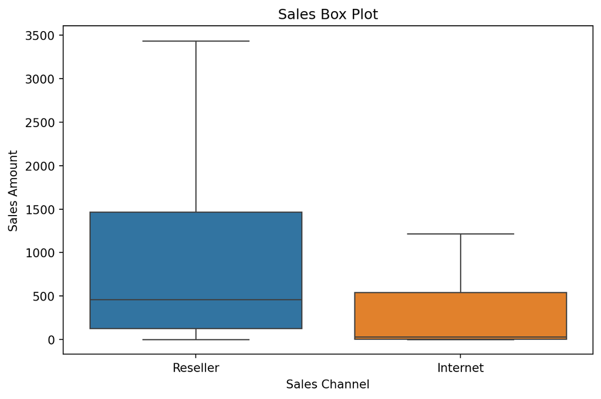

```python
plt.figure(figsize = (8,5))
sns.boxplot(data = sales_comb_customers, x = 'Channel', y = 'Sales Amount', hue = 'Channel', showfliers = False)
plt.title('Sales Box Plot')
plt.ylabel('Sales Amount')
plt.xlabel('Sales Channel')
plt.show()
```

**With Outliers**

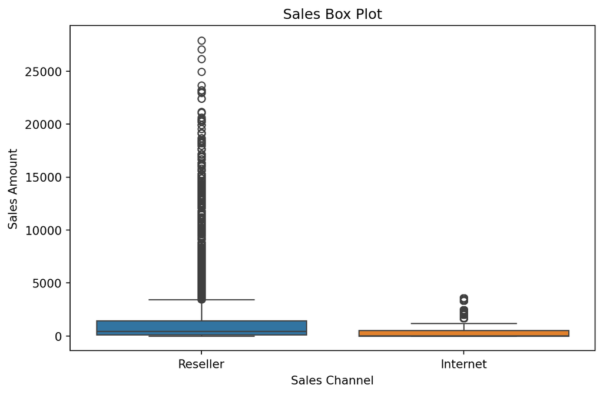

```python
plt.figure(figsize = (8,5))
sns.boxplot(data = sales_comb_customers, x = 'Channel', y = 'Sales Amount', hue = 'Channel' )
plt.title('Sales Box Plot')
plt.ylabel('Sales Amount')
plt.xlabel('Sales Channel')
plt.show()
```

### 3.2 Histogram

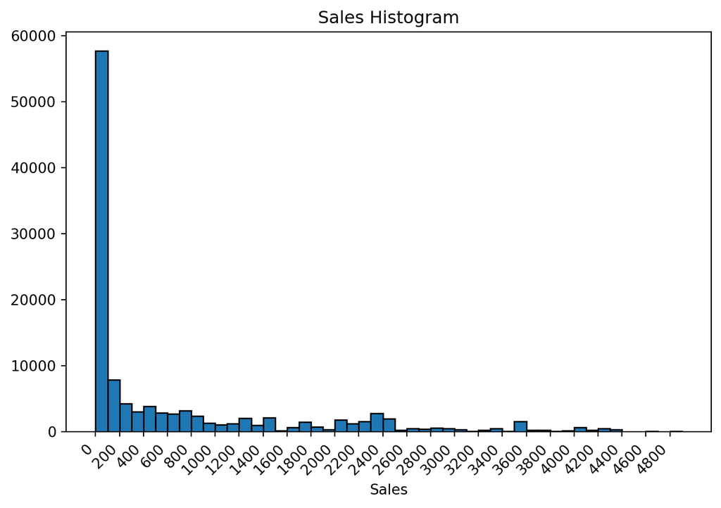

```python
plt.figure(figsize = (8,5))
plt.hist(data = sales_comb_customers, x = 'Sales Amount', bins = range(0,5000,100), edgecolor = 'black')
plt.title('Sales Histogram')
plt.xlabel('Sales')
plt.xticks(range(0,5000,200),ha = 'right', rotation = 45)
plt.show()
```

## 4 Variable Creation and Modification

Having reviewed the data, we proceed to create a new variable and rename the date column to reflect the purchase order date. We will then immediately view the dataframe information to confirm that the changes have taken effect.

```python
sales_comb_customers.rename(columns = {'Date':'Order Date'}, inplace = True)

sales_comb_customers['Profit'] = sales_comb_customers['Sales Amount'] - sales_comb_customers['Total Product Cost']
sales_comb_customers['Profit Margin'] = sales_comb_customers['Profit']/sales_comb_customers['Sales Amount']
sales_comb_customers.info()
```

```
<class 'pandas.core.frame.DataFrame'>
RangeIndex: 121253 entries, 0 to 121252
Data columns (total 34 columns):
 #   Column                   Non-Null Count   Dtype
---  ------                   --------------   -----
 0   Order Quantity           121253 non-null  int64
 1   Unit Price               121253 non-null  float64
 2   Extended Amount          121253 non-null  float64
 3   Unit Price Discount Pct  121253 non-null  int64
 4   Product Standard Cost    121253 non-null  float64
 5   Total Product Cost       121253 non-null  float64
 6   Sales Amount             121253 non-null  float64
 7   Customer ID              121253 non-null  object
 8   Customer                 121253 non-null  object
 9   City_x                   121253 non-null  object
```

[output cut: 26 more lines]

```python
sales_comb_customers.head()
```

|  | Order Quantity | Unit Price | Extended Amount | Unit Price Discount Pct | Product Standard Cost | Total Product Cost | Sales Amount | Customer ID | Customer | City_x | State-Province_x | Country-Region_x | Postal Code_x | SKU | Product | Standard Cost | Color | List Price | Model | Subcategory | Category | Channel | Sales Order | Sales Order Line | Region | Country | Group | Order Date | Fiscal Year | … |
| --- | --- | --- | --- | --- | --- | --- | --- | --- | --- | --- | --- | --- | --- | --- | --- | --- | --- | --- | --- | --- | --- | --- | --- | --- | --- | --- | --- | --- | --- | --- |
| 0 | 1 | 2024.994 | 2024.994 | 0 | 1898.0944 | 1898.0944 | 2024.994 | [Not Applicable] | [Not Applicable] | [Not Applicable] | [Not Applicable] | [Not Applicable] | [Not Applicable] | BK-M82B-42 | Mountain-100 Black, 42 | 1898.0944 | Black | 3374.99 | Mountain-100 | Mountain Bikes | Bikes | Reseller | SO43659 | SO43659 - 1 | Southeast | United States | North America | 2017-07-02 | FY2018 | … |
| 1 | 3 | 2024.994 | 6074.982 | 0 | 1898.0944 | 5694.2832 | 6074.982 | [Not Applicable] | [Not Applicable] | [Not Applicable] | [Not Applicable] | [Not Applicable] | [Not Applicable] | BK-M82B-44 | Mountain-100 Black, 44 | 1898.0944 | Black | 3374.99 | Mountain-100 | Mountain Bikes | Bikes | Reseller | SO43659 | SO43659 - 2 | Southeast | United States | North America | 2017-07-02 | FY2018 | … |
| 2 | 1 | 2024.994 | 2024.994 | 0 | 1898.0944 | 1898.0944 | 2024.994 | [Not Applicable] | [Not Applicable] | [Not Applicable] | [Not Applicable] | [Not Applicable] | [Not Applicable] | BK-M82B-48 | Mountain-100 Black, 48 | 1898.0944 | Black | 3374.99 | Mountain-100 | Mountain Bikes | Bikes | Reseller | SO43659 | SO43659 - 3 | Southeast | United States | North America | 2017-07-02 | FY2018 | … |
| 3 | 1 | 2039.994 | 2039.994 | 0 | 1912.1544 | 1912.1544 | 2039.994 | [Not Applicable] | [Not Applicable] | [Not Applicable] | [Not Applicable] | [Not Applicable] | [Not Applicable] | BK-M82S-38 | Mountain-100 Silver, 38 | 1912.1544 | Silver | 3399.99 | Mountain-100 | Mountain Bikes | Bikes | Reseller | SO43659 | SO43659 - 4 | Southeast | United States | North America | 2017-07-02 | FY2018 | … |
| 4 | 1 | 2039.994 | 2039.994 | 0 | 1912.1544 | 1912.1544 | 2039.994 | [Not Applicable] | [Not Applicable] | [Not Applicable] | [Not Applicable] | [Not Applicable] | [Not Applicable] | BK-M82S-42 | Mountain-100 Silver, 42 | 1912.1544 | Silver | 3399.99 | Mountain-100 | Mountain Bikes | Bikes | Reseller | SO43659 | SO43659 - 5 | Southeast | United States | North America | 2017-07-02 | FY2018 | … |

## 5 Segmentation

We will create a Dataframe focused on customer segmentation using the RFM (Recency, Frequency, and Monetary Value) framework.

```python
snapshot_date =  sales_comb_customers['Order Date'].max() + dt.timedelta(days = 1)

Customer_mask = sales_comb_customers['Channel'] == 'Internet'

rfm = sales_comb_customers[Customer_mask].groupby(['Customer ID','Customer'], as_index= False).agg({'Order Date': lambda x: (snapshot_date - x.max()).days,
                                                                   'Sales Order':'nunique', 'Sales Amount':'sum'}).rename(columns = {'Order Date':'Recency',
                                                                                                                                      'Sales Order': 'Frequency',
                                                                                                                                      'Sales Amount': 'Monetary Value'
                                                                                                                                     })

rfm.head()
```

|  | Customer ID | Customer | Recency | Frequency | Monetary Value |
| --- | --- | --- | --- | --- | --- |
| 0 | AW00011000 | Jon Yang | 256 | 3 | 8248.99 |
| 1 | AW00011001 | Eugene Huang | 35 | 3 | 6383.88 |
| 2 | AW00011002 | Ruben Torres | 325 | 3 | 8114.04 |
| 3 | AW00011003 | Christy Zhu | 249 | 3 | 8139.29 |
| 4 | AW00011004 | Elizabeth Johnson | 258 | 3 | 8196.01 |

### 5.1 Inertia and Silhouette Tests

Using metrics within the `sklearn` library, we proceed to confirm the ideal selection of the number of clusters we will need and whether they align with the RFM framework we have chosen. To do this, we need to standardize the data from the newly created RFM dataframe and define functions. The first metric to calculate will be inertia.

```python
rfm_scaled = StandardScaler().fit_transform(rfm.iloc[:,2:])

num_clusters = [i for i in range(2, 11)]

def kmeans_inertia(num_clusters, x_vals):
    inertia = []
    for num in num_clusters:
        kms = KMeans(n_clusters=num, random_state=42, n_init = 10)
        kms.fit(x_vals)
        inertia.append(kms.inertia_)

    return inertia
```

```python
inertia = kmeans_inertia(num_clusters, rfm_scaled)
inertia
```

```
[37782.45059151246,
 28151.903144645315,
 19076.850342141173,
 13390.85930806318,
 11244.581537166076,
 9395.945586720052,
 8231.121768348952,
 7345.660813153022,
 6557.033770775004]
```

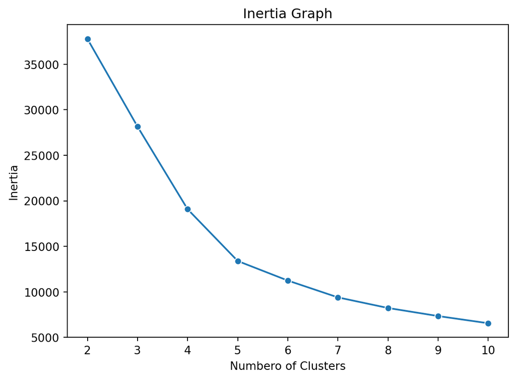

```python
plot = sns.lineplot(x=num_clusters, y=inertia, marker = 'o')
plt.title('Inertia Graph')
plt.xlabel('Numbero of Clusters')
plt.ylabel('Inertia')
plt.show()
```

**Interpretation**

Here we can see how the “elbow” in this line graph shows that the slope begins to change from the fourth cluster onward, but this change becomes even more pronounced after the fifth. Based on this, we could say that both options regarding the number of clusters would be acceptable; however, we will perform another test with the silhouette coefficient, defining a different function to confirm.

```python
def kmeans_sil(num_clusters, x_vals):
    sil_score = []
    for num in num_clusters:
        kms = KMeans(n_clusters=num, random_state=42, n_init = 10)
        kms.fit(x_vals)
        sil_score.append(silhouette_score(x_vals, kms.labels_))

    return sil_score


sil_score = kmeans_sil(num_clusters, rfm_scaled)
sil_score
```

```
[0.4952389414729153,
 0.4735051767670395,
 0.5120628727424589,
 0.42328143194209644,
 0.4183038987410263,
 0.4246190071689267,
 0.43170154807749855,
 0.434606570599305,
 0.4352608581124152]
```

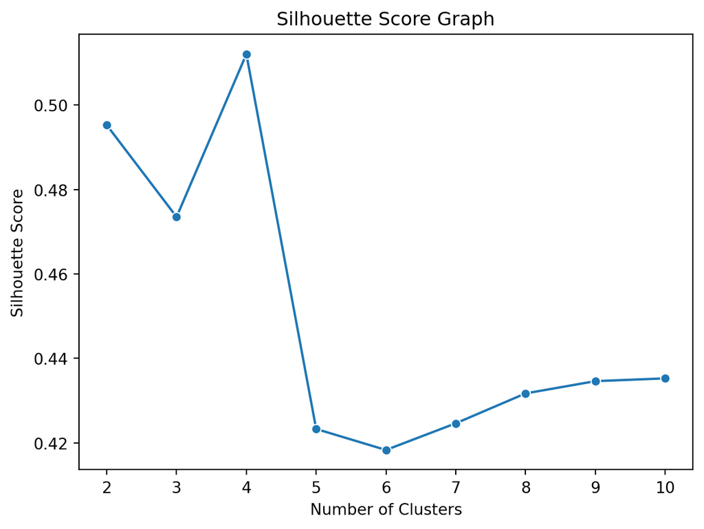

```python
plot = sns.lineplot(x=num_clusters, y=sil_score, marker = 'o')
plt.title('Silhouette Score Graph')
plt.xlabel('Number of Clusters')
plt.ylabel('Silhouette Score')
plt.show()
```

**Interpretation**

The sharp drop from the fourth cluster onward, where it reaches a maximum value of 0.51, indicates that there is indeed a real distinction between clusters, since exceeding 0.5 is an excellent indicator that the segments truly “exist” and are not simply noise.

While it is true that the 4-cluster model fits perfectly with the classic theory of customer segmentation, it is certainly important to also justify the choice through technical criteria.

### 5.2 Implementing Clustering Model

We applied a K-means model so that, based on the RFM variables we created, each customer is assigned to one of four segments. To avoid errors and prevent the model from assigning weight to variables with a higher scale, we standardized the variables using `StandardScaler()` and `fit_transform()`, while maintaining a replicable result by providing a seed or “random state” of 42.

The cluster assignment result is then added to the “RFM” dataframe, which in turn allows us to append the “Cluster” variable to our previous final dataframe, “sales_comb_customers,” using the `merge()` function.

```python
kmeans = KMeans(n_clusters = 4, random_state = 42, n_init = 10)
rfm['Cluster'] = kmeans.fit_predict(rfm_scaled)

rfm.head()
```

|  | Customer ID | Customer | Recency | Frequency | Monetary Value | Cluster |
| --- | --- | --- | --- | --- | --- | --- |
| 0 | AW00011000 | Jon Yang | 256 | 3 | 8248.99 | 3 |
| 1 | AW00011001 | Eugene Huang | 35 | 3 | 6383.88 | 3 |
| 2 | AW00011002 | Ruben Torres | 325 | 3 | 8114.04 | 3 |
| 3 | AW00011003 | Christy Zhu | 249 | 3 | 8139.29 | 3 |
| 4 | AW00011004 | Elizabeth Johnson | 258 | 3 | 8196.01 | 3 |

We grouped the data by cluster using the average of the RFM variables to be able to preliminarily observe them in table format:

```python
summarized_rfm= rfm.groupby('Cluster',as_index = False).agg({'Recency':'mean', 'Frequency':'mean' ,
                                            'Monetary Value':'mean',
                                            'Customer ID':'count'}).rename(columns = {'Recency':'Avg Recency (Days)',
                                                                                        'Frequency':'Avg Frequency (Orders)',
                                                                                        'Monetary Value':'Avg Monetary Value ($)',
                                                                                         'Customer ID':'Num Customers'}).round()
summarized_rfm
```

|  | Cluster | Avg Recency (Days) | Avg Frequency (Orders) | Avg Monetary Value ($) | Num Customers |
| --- | --- | --- | --- | --- | --- |
| 0 | 0 | 841.0 | 1.0 | 2937.0 | 405 |
| 1 | 1 | 162.0 | 1.0 | 504.0 | 13648 |
| 2 | 2 | 11.0 | 21.0 | 986.0 | 35 |
| 3 | 3 | 158.0 | 2.0 | 4835.0 | 4396 |

By observing the results of our clustering, we can define these clusters as follows:

- 0: Lost Customers (841 days since their last order).
- 1: Standard Customers (our largest cluster with 13,648 customers).
- 2: Very Active Customers (only 11 days since their last order).
- 3: High-Value Customers (This cluster represents the highest level of spending/purchase value).

Now we will complete our dataframe with the created clusters and export them for later use. We will export “rfm” and “sales_comb_clustered”.

```python
segments = {0:'Clientes perdidos', 1:'Clientes estándar', 2:'Clientes Muy Activos', 3:'Clientes de Alto Valor'}

summarized_rfm['Segments'] =  summarized_rfm['Cluster'].map(segments)
summarized_rfm
```

|  | Cluster | Avg Recency (Days) | Avg Frequency (Orders) | Avg Monetary Value ($) | Num Customers | Segments |
| --- | --- | --- | --- | --- | --- | --- |
| 0 | 0 | 841.0 | 1.0 | 2937.0 | 405 | Clientes perdidos |
| 1 | 1 | 162.0 | 1.0 | 504.0 | 13648 | Clientes estándar |
| 2 | 2 | 11.0 | 21.0 | 986.0 | 35 | Clientes Muy Activos |
| 3 | 3 | 158.0 | 2.0 | 4835.0 | 4396 | Clientes de Alto Valor |

```python
sales_comb_clustered = sales_comb_customers.merge(rfm[['Customer ID', 'Cluster']], how = 'left', on = 'Customer ID')
sales_comb_clustered.to_csv('C:/Users/gicr9/Downloads/sales_comb_clustered.csv', index = False)
rfm.to_csv('C:/Users/gicr9/Downloads/rfm.csv', index = False)
```

### 5.3 Visualizing Segments

We will now visualize the different segments using a scatter plot.

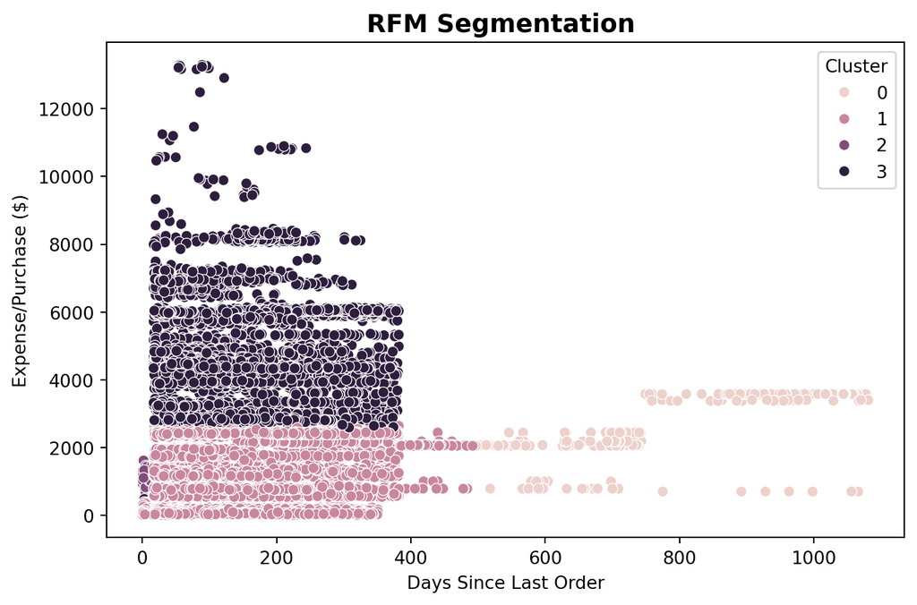

```python
plt.figure(figsize = (8,5))

sns.scatterplot(data = rfm, x = 'Recency', y = 'Monetary Value', hue = 'Cluster')
plt.xlabel('Days Since Last Order')
plt.ylabel('Expense/Purchase ($)')
plt.title('RFM Segmentation ', size = 14, fontweight='bold')

plt.show()
```

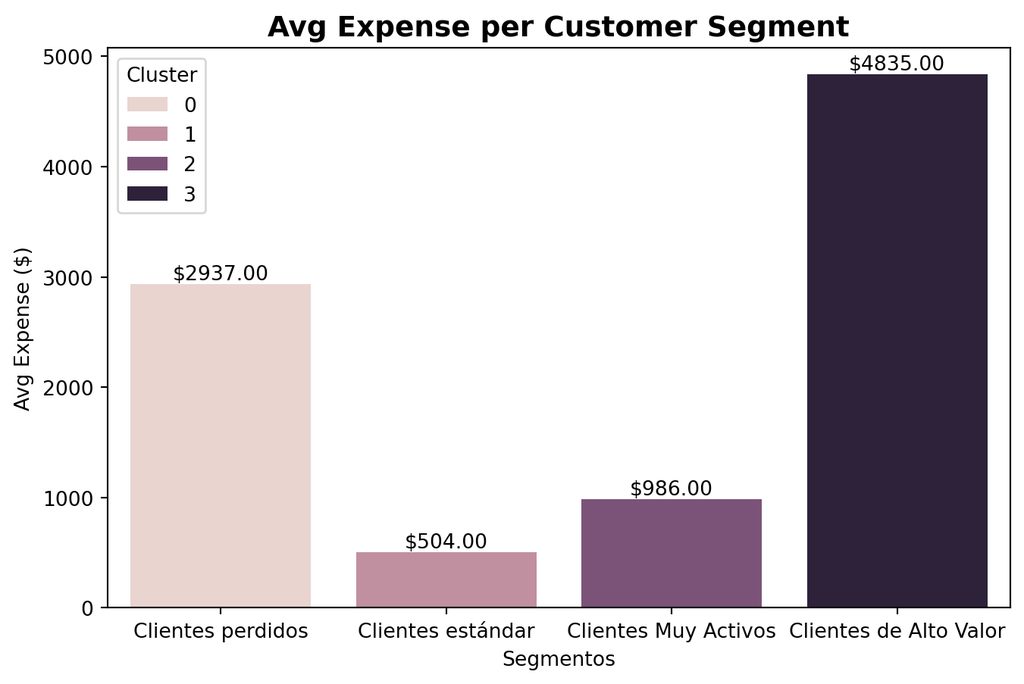

```python
plt.figure(figsize = (8,5))

m_bar = sns.barplot(data = summarized_rfm, x = 'Segments', y = 'Avg Monetary Value ($)', hue = 'Cluster')
plt.xlabel('Segmentos')
plt.ylabel('Avg Expense ($)')
plt.title('Avg Expense per Customer Segment', size = 14, fontweight='bold')
for container in m_bar.containers:
    m_bar.bar_label(container, fmt='$%.2f')

plt.show()
```